# Getting started with Python and Notebooks

## Intro

Notebooks are a great introduction to using Python, and we use them extensively in Ricardo. They allow us to combine text and code to combine analysis and reporting in one place. This tutorial was made with a notebook.

## Installing Python and Jupyter

The Jupyter Notebook App allows you to edit and run your notebooks in a web browser. The best way to get started is by installing Anaconda distribution, which gives you both Python and Jupyter Notebooks, plus most of the data analysis packages that you will need.

- Follow the instruction guide here: https://docs.anaconda.com/anaconda/install/windows/
- Make sure you install Anaconda, not miniconda

You'll find everything under Anaconda Navigator in your start bar - it's worth pinning Jupyter Notebook to the taskbar at this point so that you can easily find it.

Finding Jupyter

[figure not shown]

## Your first notebook

When the notebook opens in your browser, you will see the Notebook Dashboard, which will show a list of the notebooks, files, and subdirectories in the directory where the notebook server was started.

Notebook dashboard

[figure not shown]

Browse to the folder in which you would like to create your first notebook, click the “New” drop-down button in the top-right and select “Python 3”

Create a new notebook

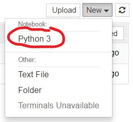

Your Jupyter Notebook will open in new tab.